# Lecture Script - General Linear Model

Bioengineering Statistics (MA482/BE482)

```r
# This line should be the first line of code executed in your document. It
# ensures that additional functionality is available to you.
source("https://reyesem.github.io/files/MA482/MA482Setup.R")
```

This module contains code for modeling a quantitative response as a linear combination of predictors. Specifically, we are considering a model of the form

$$(\text{Response})_i = \beta_0 + \sum_{j=1}^{p} \beta_j (\text{Predictor } j)_i + \epsilon_i$$

While the models discussed in this module all have this general form, many of the modeling strategies we introduce are not specific to this general linear model and can be used in future models. As we move though the code, be sure to differentiate the topics which are specific to the linear model and those which are general modeling strategies.

## The Model Framework

As always, we need to begin by reading in the data.

```r
strep <- read_csv("StrepOutbreak.csv")
```

It is tempting to launch into modeling immediately, but it is always a good idea to get a feel for the data. While we will not spend a ton of time doing exploratory analyses, we do want to get an overview of the data.

In the following code, we make use of the “pipe operator” (`%>%`). It takes the thing on the left-hand side and throws it into the function on the right-hand side. So, we begin with the `strep` dataset which we had read in, and then (`%>%`) we select out the variables we want to keep, and then (`%>%`) we summarize those variables.

Notice that some of the variables have strange names. This is common in medical datasets; it is helpful to refer to the codebook on the course site, which gives a list of all variables in the dataset and their computation/units, etc.

```r
# Only summarize variables being considered for model.
strep %>%
  select(losdays, age, temp, hrtrate, resprate) %>%
  skim()
```

```
Skim summary statistics
 n obs: 83
 n variables: 5

-- Variable type:numeric -------------------------------------------------------------------------------------
 variable missing complete  n   mean    sd   p0  p25   p50   p75  p100
      age       0       83 83  19.64  2.37 18   18    19    20    33
  hrtrate       0       83 83  89.73 17.78 59   77.5  88   101   134
  losdays       0       83 83   3.36  4.67  1    1     2     4    34
 resprate       0       83 83  20.57  5.25 12   18    20    24    40
     temp       0       83 83  99.82  2.13 95.6 98.2  99.5 101.2 105.6
```

The most commonly used function for fitting a linear model is the `lm()` function. It has the following requirements:

- Response: the name of the variable to be treated as the response is on the left-hand side of the `~`.
- Predictors: on the right-hand side of the `~` are the predictors to be placed in the model, always separated by a `+`. You are simply communicating that for each element separated by a plus sign, there should be a coefficient attached to it in the modeling framework.
- Data: the computer needs to know in what dataset to look for the variables you have listed.

If you want to know more information about any function in R, simply type `help("function_name")` into the console (at the prompt `>`). For example, `help("lm")` will pull up documentation for the `lm()` function. You should note that R documentation is not always the most user friendly for beginners.

Now, the `lm()` function is a workhorse; it computes the estimates, along with many other characteristics of the model. You want to store that information so that you can easily access it. So, you want to assign that output a name (in this case `fit.strep`).

The estimates of the model can be obtained with the `tidy()` function, and the model fit can be summarized using the `glance()` function. Adding the option `conf.int = TRUE` to the tidy function produces confidence intervals; the option `conf.level = 0.95` sets the confidence level (default being 0.95).

```r
# Fit Linear Model
#  The least-squares fit is really an object, which is stored.
fit.strep <- lm(losdays ~ age + temp + hrtrate + resprate,
                data=strep)


# Examine Coefficients
#  tidy() gives a summary of the coefficients
tidy(fit.strep, conf.int = TRUE)
```

```
# A tibble: 5 x 7
  term        estimate std.error statistic  p.value conf.low conf.high
  <chr>          <dbl>     <dbl>     <dbl>    <dbl>    <dbl>     <dbl>
1 (Intercept)   30.2     21.9         1.38 0.172    -13.4      73.7
2 age           -0.249    0.176      -1.41 0.161     -0.598     0.101
3 temp          -0.385    0.231      -1.67 0.0995    -0.844     0.0748
4 hrtrate        0.123    0.0307      4.01 0.000136   0.0621    0.184
5 resprate       0.265    0.0899      2.94 0.00429    0.0856    0.444
```

```r
# Examine Model Fit
#  glance() produces summaries of the model fit
glance(fit.strep)
```

```
# A tibble: 1 x 11
  r.squared adj.r.squared sigma statistic p.value    df logLik   AIC   BIC
      <dbl>         <dbl> <dbl>     <dbl>   <dbl> <int>  <dbl> <dbl> <dbl>
1     0.392         0.360  3.74      12.6 6.22e-8     5  -225.  461.  476.
# ... with 2 more variables: deviance <dbl>, df.residual <int>
```

## Related Predictors

The code in this section highlights the use of regression models to adjust for confounding. The one new element we consider is the idea of adding layers to scatterplots to visualize the relationship within groups.

```r
penn <- read_csv("PennState.csv")
```

The following simple graphic shows the relationship between the fastest a student has ever driven a vehicle and their height. A “smoother” has been overlayed (using `geom_smooth()`) to help visualize the increasing trend in the data.

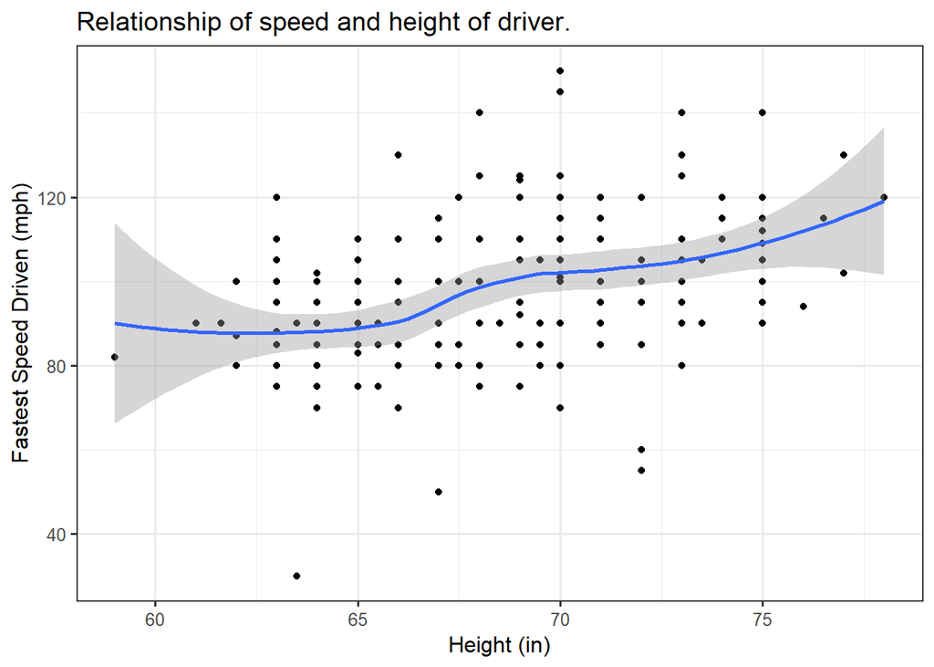

```r
# geom_smooth() adds a smoother to a graphic.
ggplot(data = penn,
       mapping = aes(y = Fastest, x = Height)) +
  geom_point() +
  geom_smooth() +
  labs(title = "Relationship of speed and height of driver.",
       y = "Fastest Speed Driven (mph)",
       x = "Height (in)")
```

The linear relationship depicted in the graphic can be captured in the following linear model.

```r
fit1.penn <- lm(Fastest ~ Height, data = penn)

tidy(fit1.penn)
```

```
# A tibble: 2 x 5
  term        estimate std.error statistic      p.value
  <chr>          <dbl>     <dbl>     <dbl>        <dbl>
1 (Intercept)   -26.2     21.0       -1.25 0.213
2 Height          1.81     0.307      5.89 0.0000000175
```

A second look at the data reveals that there is a reason for the curious relationship seen in the graphic above. Here, we want to bring out a grouping variable — gender. We use color to denote the various genders in the graphic. Note that by mapping color to a variable in the dataset early on, it affects everything that gets constructed from then on.

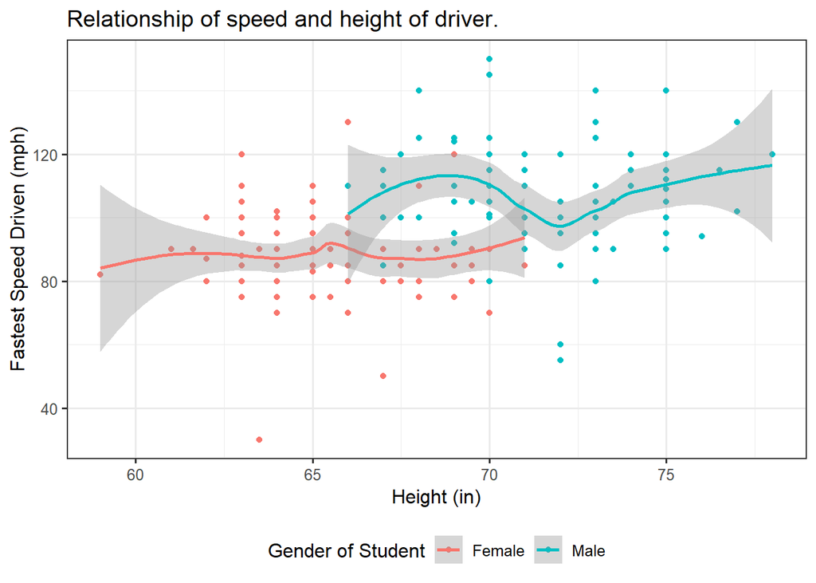

```r
# Add color aesthetic to show different genders
ggplot(data = penn,
       mapping = aes(y = Fastest, x = Height, color = Sex)) +
  geom_point() +
  geom_smooth() +
  labs(title = "Relationship of speed and height of driver.",
       y = "Fastest Speed Driven (mph)",
       x = "Height (in)",
       color = "Gender of Student")
```

The updated model shows that height is not associated with the speed a student drives the car *after* accounting for the gender of the student.

```r
fit2.strep <- lm(Fastest ~ Height + Sex, data = penn)

tidy(fit2.strep)
```

```
# A tibble: 3 x 5
  term        estimate std.error statistic     p.value
  <chr>          <dbl>     <dbl>     <dbl>       <dbl>
1 (Intercept)  85.5       29.0       2.94  0.00365
2 Height        0.0446     0.443     0.101 0.920
3 SexMale      18.7        3.59      5.22  0.000000471
```

If the above example is somewhat confusing in terms of how the model handled a categorical variable like gender, we will describe that in the next section.

## Categorical Covariates

While we discuss the modeling aspects of addressing categorical predictors, from a computational standpoint, the computer handles this automatically provided that the variable is recognized as categorical by the computer (either a character variable or factor in R). If in doubt, mutate the dataset so that the categorical variable is a factor using the `factor()` function.

```r
chick <- read_csv("BroilderChickens.csv")
```

Below is a linear model; since `Diet` and `Gender` are both categorical variables (coded as character variables in the program), these are handled automatically. The level indicated by the 1 in the indicator variable is denoted by appending that level to the end of the name of the variable in the `term` column of the results.

```r
fit.chick <- lm(SeLiver ~ Diet + Gender + SeDiet + FeedPeriod, data = chick)

tidy(fit.chick, conf.int = TRUE)
```

```
# A tibble: 5 x 7
  term        estimate std.error statistic  p.value conf.low conf.high
  <chr>          <dbl>     <dbl>     <dbl>    <dbl>    <dbl>     <dbl>
1 (Intercept)   0.0872    0.148      0.590 5.57e- 1  -0.208      0.382
2 DietB         0.113     0.0840     1.35  1.82e- 1  -0.0544     0.281
3 GenderMale    0.195     0.0840     2.32  2.34e- 2   0.0272     0.363
4 SeDiet        3.36      0.515      6.52  1.06e- 8   2.33       4.39
5 FeedPeriod    0.378     0.0257    14.7   1.19e-22   0.327      0.430
```

## Interaction Terms (Effect Modifications)

Allowing the effect of one variable to be modified by another variable can be done by including products into the model.

Before launching into the model, we recognize that the variable `strepa` in the dataset is not categorical. While (in this case) we need not make changes, we recommend making the variable a bit clearer to read in the output. So, we perform a little manipulation, which is done with the `mutate()` function. We are “recoding” the variable.

```r
# Convert strep variable into a categorical variable.
# The original data is overwritten.
strep <- strep %>%
  mutate(strepa = recode(strepa,
                         `0` = "Other",
                         `1` = "Strep A"))
```

Now, we fit a model with the interaction between heart rate and the type of pneumonia in the model. This is done by adding a product of the two variables, denoted with `:` in the model statement.

```r
fit2.strep <- lm(losdays ~ hrtrate + strepa + temp + hrtrate:strepa,
                 data = strep)

tidy(fit2.strep, conf.int = TRUE)
```

```
# A tibble: 5 x 7
  term             estimate std.error statistic  p.value conf.low conf.high
  <chr>               <dbl>     <dbl>     <dbl>    <dbl>    <dbl>     <dbl>
1 (Intercept)        8.43     21.6        0.390 0.698    -3.46e+1    51.5
2 hrtrate            0.0691    0.0337     2.05  0.0436    2.04e-3     0.136
3 strepaStrep A    -16.2       4.56      -3.56  0.000645 -2.53e+1    -7.13
4 temp              -0.119     0.233     -0.513 0.610    -5.83e-1     0.344
5 hrtrate:strepaS~   0.203     0.0498     4.08  0.000110  1.04e-1     0.302
```

For such a simple model, we can visualize the results to some degree by allowing color to distinguish the two groups in the model. Notice that the lines are not parallel.

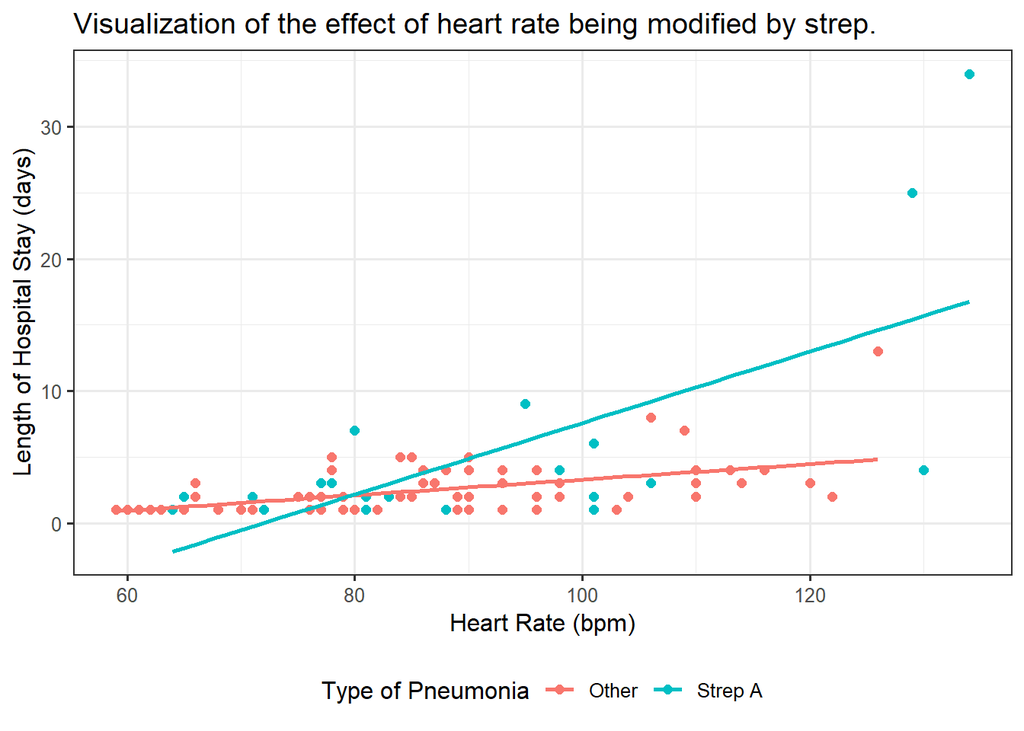

```r
ggplot(data = strep,
       mapping = aes(y = losdays, x = hrtrate, color = strepa)) +
  geom_point(size = 2) +
  geom_smooth(method = "lm", se = FALSE) +
  labs(y = "Length of Hospital Stay (days)",
       x = "Heart Rate (bpm)",
       color = "Type of Pneumonia",
       title = "Visualization of the effect of heart rate being modified by strep.")
```

## General Linear Hypothesis

Performing a general linear hypothesis test is done through the `linearHypothesis()` function. There is a bit of a learning curve here because we must specify the $\mathbf{K}$ matrix and $\mathbf{m}$ vector to the computer.

The model we are interested in is summarized again below. Note: it is important to look at the output of the model before writing a generalized linear hypothesis because the order matters.

```
# A tibble: 5 x 5
  term        estimate std.error statistic  p.value
  <chr>          <dbl>     <dbl>     <dbl>    <dbl>
1 (Intercept)   0.0872    0.148      0.590 5.57e- 1
2 DietB         0.113     0.0840     1.35  1.82e- 1
3 GenderMale    0.195     0.0840     2.32  2.34e- 2
4 SeDiet        3.36      0.515      6.52  1.06e- 8
5 FeedPeriod    0.378     0.0257    14.7   1.19e-22
```

Suppose we are interested in testing the following hypothesis:

$$H_0: \beta_1 = \beta_2 = \beta_3 = \beta_4 = 0 \qquad \text{vs.} \qquad H_1: \text{At least one differs}$$

Then, our $\mathbf{K}$ matrix has the form

$$\mathbf{K} = \begin{pmatrix}
0 & 1 & 0 & 0 & 0 \\
0 & 0 & 1 & 0 & 0 \\
0 & 0 & 0 & 1 & 0 \\
0 & 0 & 0 & 0 & 1
\end{pmatrix}$$

and the $\mathbf{m}$ vector is the vector of all 0’s. We build the $\mathbf{K}$ matrix in R using the `matrix()` function. This function takes a matrix wrapped in the `c()` function; but, you must also specify the number of rows and columns that the matrix will have.

```r
# Be sure to use byrow = TRUE so that it loads the way it looks.
K1 <- matrix(
  c(0, 1, 0, 0, 0,
    0, 0, 1, 0, 0,
    0, 0, 0, 1, 0,
    0, 0, 0, 0, 1),
  nrow = 4, ncol = 5, byrow = TRUE
)
```

The `linearyHypothesis()` function takes in both the model and the K-matrix. Since our m-vector is all 0’s, we do not need to supply it. The results print out a summary of what was tested, along with the standardized statistic and the resulting p-value.

```r
linearHypothesis(fit.chick, hypothesis.matrix = K1)
```

```
Linear hypothesis test

Hypothesis:
DietB = 0
GenderMale = 0
SeDiet = 0
FeedPeriod = 0

Model 1: restricted model
Model 2: SeLiver ~ Diet + Gender + SeDiet + FeedPeriod

  Res.Df    RSS Df Sum of Sq      F    Pr(>F)
1     71 42.331
2     67  8.519  4    33.811 66.477 < 2.2e-16 ***
---
Signif. codes:  0 '***' 0.001 '**' 0.01 '*' 0.05 '.' 0.1 ' ' 1
```

and the $\mathbf{m}$ vector is

$$\mathbf{m} = \begin{pmatrix} 0.15 \\ 0.15 \end{pmatrix}$$

These are again specified in R where we note that the m-vector is specified using the `c()` function.

```r
K2 <- matrix(
  c(0, 1, 0, 0, 0,
    0, 0, 1, 0, 0),
  nrow = 2, ncol = 5, byrow = TRUE
)

# m is defined using the c() function
m <- c(0.15, 0.15)
```

We can specify the m-vector using the `rhs =` option in the `linearHypothesis()` function.

```r
linearHypothesis(fit.chick, hypothesis.matrix = K2, rhs = m)
```

```
Linear hypothesis test

Hypothesis:
DietB = 0.15
GenderMale = 0.15

Model 1: restricted model
Model 2: SeLiver ~ Diet + Gender + SeDiet + FeedPeriod

  Res.Df    RSS Df Sum of Sq      F Pr(>F)
1     69 8.5800
2     67 8.5193  2   0.06065 0.2385 0.7885
```

## Assessing Assumptions

Our ability to make inference required us to make certain conditions on the model. We now turn to using the data to determine if these conditions are reasonable.

We continue with the model for the Broiler Chicken example

$$\begin{aligned}
(\text{Se in Liver})_i &= \beta_0 + \beta_1 (\text{Diet B})_i + \beta_2 (\text{Male})_i \\
&\qquad + \beta_3(\text{Se in Diet})_i + \beta_4 (\text{Feed Period})_i + \varepsilon_i
\end{aligned}$$

which is summarized below

```
# A tibble: 5 x 5
  term        estimate std.error statistic  p.value
  <chr>          <dbl>     <dbl>     <dbl>    <dbl>
1 (Intercept)   0.0872    0.148      0.590 5.57e- 1
2 DietB         0.113     0.0840     1.35  1.82e- 1
3 GenderMale    0.195     0.0840     2.32  2.34e- 2
4 SeDiet        3.36      0.515      6.52  1.06e- 8
5 FeedPeriod    0.378     0.0257    14.7   1.19e-22
```

In order to assess the conditions on the model, we must compute the residuals. This is done with the `augment()` function. It will augment a dataset with diagnostic tools for assessing a model, including residuals and fitted values (as well as others which are beyond the scope of this course but are discussed in a regression course).

```r
# The resulting diagnostics and variables are stored in aug.chick.
aug.chick <- augment(fit.chick, data = chick)
```

To assess the “Mean 0” condition, we plot the residuals (stored as `.resid` in the augmented dataset) against the fitted values (stored ast `.fitted` in the augmented dataset). This plot is also used to assess the “Constant Variance” condition.

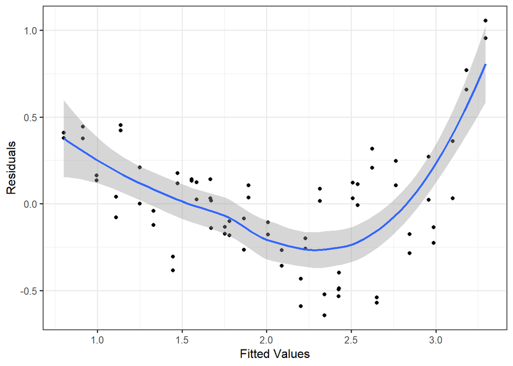

```r
# Adding a smoother can help identify trends.
# Do not overinterpret smoother.
ggplot(data = aug.chick,
       mapping = aes(y = .resid, x = .fitted)) +
  geom_point() +
  geom_smooth() +
  labs(y = "Residuals",
       x = "Fitted Values")
```

While a time-series plot cannot detect all departures from the “Independence” condition, it can help detect trends that occur over time. This is only helpful if the order in which the data is collected is known.

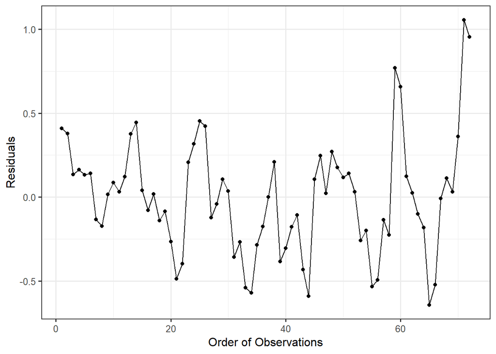

```r
# Connecting the points is helpful.
ggplot(data = aug.chick,
       mapping = aes(y = .resid, x = seq_along(.resid))) +
  geom_point() +
  geom_line() +
  labs(y = "Residuals",
       x = "Order of Observations")
```

Assessing “Normality” condition can be done using a probability (QQ) plot. It should be noted that this exact graphic is made possible by custom code constructed solely for this course. *The line drawn on the graphic if for reference purposes only and does not determine whether the points follow a linear trend*.

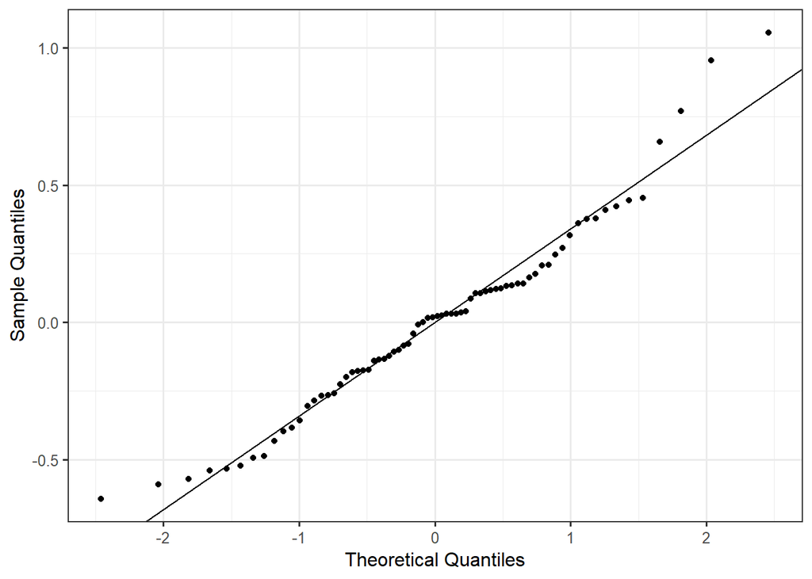

```r
ggplot(data = aug.chick,
       mapping = aes(sample = .resid)) +
  stat_qq() +
  stat_qqline() +
  labs(y = "Sample Quantiles",
       x = "Theoretical Quantiles")
```

To assess linearity of the predictors, we plot the residuals against each quantitative predictor individually.

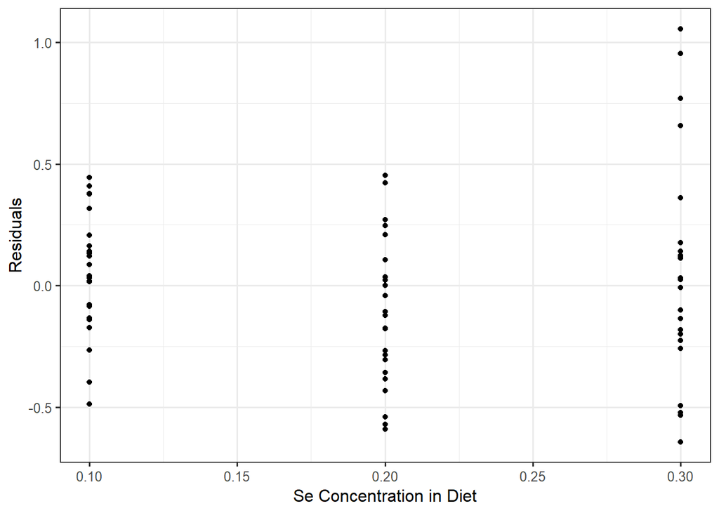

```r
ggplot(data = aug.chick,
       mapping = aes(y = .resid, x = SeDiet)) +
  geom_point() +
  labs(y = "Residuals",
       x = "Se Concentration in Diet")
```

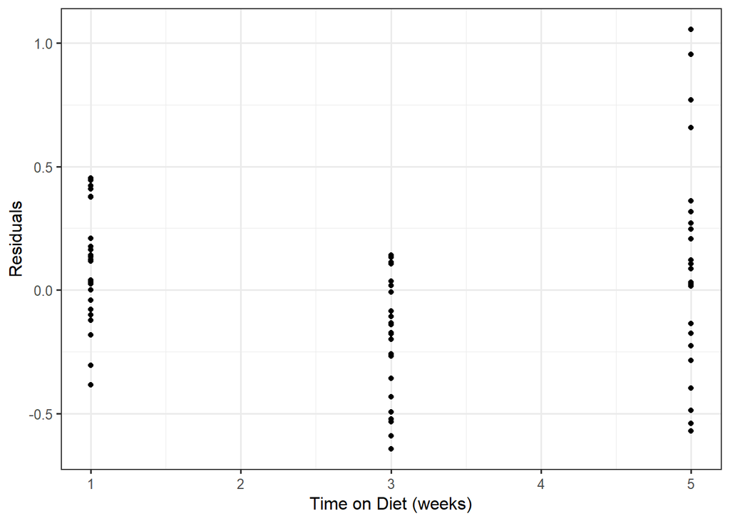

```r
ggplot(data = aug.chick,
       mapping = aes(y = .resid, x = FeedPeriod)) +
  geom_point() +
  labs(y = "Residuals",
       x = "Time on Diet (weeks)")
```

## Relaxing Assumptions

A residual bootstrap can be used to obtain confidence intervals for parameters when we do not believe it is reasonable to assume the error is Normally distributed. *Note: with the functions we are using, it is not possible to compute a p-value via bootstrapping.*

Recall the output from the classical regression modeling approach.

```
# A tibble: 5 x 7
  term        estimate std.error statistic  p.value conf.low conf.high
  <chr>          <dbl>     <dbl>     <dbl>    <dbl>    <dbl>     <dbl>
1 (Intercept)   30.2     21.9         1.38 0.172    -13.4      73.7
2 age           -0.249    0.176      -1.41 0.161     -0.598     0.101
3 temp          -0.385    0.231      -1.67 0.0995    -0.844     0.0748
4 hrtrate        0.123    0.0307      4.01 0.000136   0.0621    0.184
5 resprate       0.265    0.0899      2.94 0.00429    0.0856    0.444
```

We use the `Boot()` function to implement the bootstrap procedure. We specify the following elements:

- The model is the first element passed to the function.
- We use the `method = "residual"` option to specify a residual bootstrap.
- We use the `R = 3000` to specify the number of bootstrap replicates to perform.

We store the result for future summary. To compute the confidence intervals, we need to use the `confint()` function and specify the confidence level.

```r
# Store the results of the residual bootstrap in boot.strep
boot.strep <- Boot(fit.strep, R = 3000, method = "residual")

# Compute 95% confidence intervals.
confint(boot.strep, level = 0.95)
```

```
Bootstrap bca confidence intervals

                   2.5 %     97.5 %
(Intercept) -16.84597297 75.9785713
age          -0.53503455  0.2689749
temp         -0.86163205  0.1128132
hrtrate       0.05661324  0.1875890
resprate      0.07402480  0.4428803
```

To implement large-sample theory for computing a p-value, we simply invoke the `test = "Chisq"` option in the `linearHypothesis()` function.

```r
K <- matrix(
  c(0, 0, 0, 1, 0),
  nrow = 1, ncol = 5, byrow = TRUE
)

linearHypothesis(fit.strep, K, test = "Chisq")
```

```
Linear hypothesis test

Hypothesis:
hrtrate = 0

Model 1: restricted model
Model 2: losdays ~ age + temp + hrtrate + resprate

  Res.Df    RSS Df Sum of Sq  Chisq Pr(>Chisq)
1     79 1314.7
2     78 1089.7  1    225.04 16.109   5.98e-05 ***
---
Signif. codes:  0 '***' 0.001 '**' 0.01 '*' 0.05 '.' 0.1 ' ' 1
```

As we consider nonlinearity, it is not always possible to visualize the raw response, but when possible, it is very useful.

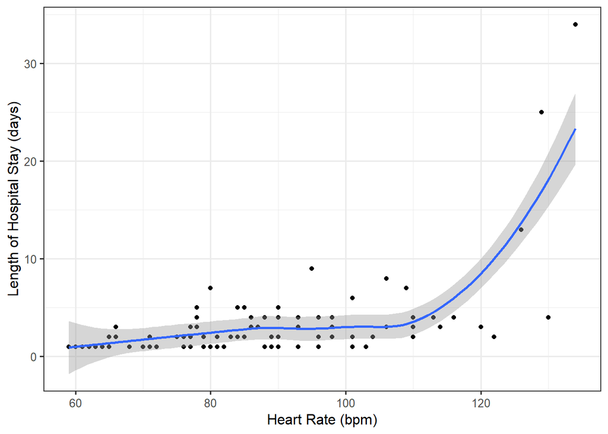

```r
ggplot(data = strep,
       mapping = aes(y = losdays, x = hrtrate)) +
  geom_point() +
  geom_smooth() +
  labs(y = "Length of Hospital Stay (days)",
       x = "Heart Rate (bpm)")
```

We can always diagnose the problem from the residual plot, but then it is less clear how to proceed with adjusting the model.

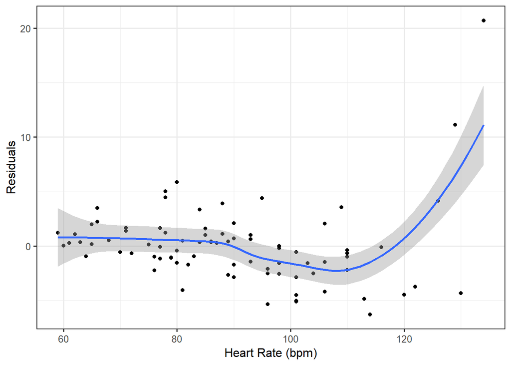

```r
aug.strep <- augment(fit.strep, data = strep)

ggplot(data = aug.strep,
       mapping = aes(y = .resid, x = hrtrate)) +
  geom_point() +
  geom_smooth() +
  labs(y = "Residuals",
       x = "Heart Rate (bpm)")
```

A linear spline can be placed in the model using the `lsp()` function and specifying the knot points. We consider the model we have previously used for the length of a hospital stay, summarized below.

```
# A tibble: 5 x 5
  term        estimate std.error statistic  p.value
  <chr>          <dbl>     <dbl>     <dbl>    <dbl>
1 (Intercept)   30.2     21.9         1.38 0.172
2 age           -0.249    0.176      -1.41 0.161
3 temp          -0.385    0.231      -1.67 0.0995
4 hrtrate        0.123    0.0307      4.01 0.000136
5 resprate       0.265    0.0899      2.94 0.00429
```

To add a linear spline, we simply change the variable on which we want a spline.

```r
fit3.strep <- lm(losdays ~ age + temp + lsp(hrtrate, c(85, 110)) +
                   resprate, data = strep)

tidy(fit3.strep)
```

```
# A tibble: 7 x 5
  term                              estimate std.error statistic    p.value
  <chr>                                <dbl>     <dbl>     <dbl>      <dbl>
1 (Intercept)                          6.24    18.8        0.332    7.41e-1
2 age                                 -0.248    0.150     -1.65     1.03e-1
3 temp                                -0.101    0.196     -0.512    6.10e-1
4 lsp(hrtrate, c(85, 110))hrtrate      0.104    0.0583     1.78     7.86e-2
5 lsp(hrtrate, c(85, 110))hrtrate'    -0.152    0.0932    -1.63     1.08e-1
6 lsp(hrtrate, c(85, 110))hrtrate''    0.728    0.126      5.77     1.62e-7
7 resprate                             0.153    0.0766     2.00     4.87e-2
```

The nice thing about linear splines is that we can test whether the additional complexity is needed.

```r
K.linear <- matrix(
  c(0, 0, 0, 0, 1, 0, 0,
    0, 0, 0, 0, 0, 1, 0),
  nrow = 2, ncol = 7, byrow = TRUE
)

linearHypothesis(fit3.strep, K.linear)
```

```
Linear hypothesis test

Hypothesis:
lsp(hrtrate, c(85, 110))hrtrate' = 0
lsp(hrtrate, c(85, 110))hrtrate'' = 0

Model 1: restricted model
Model 2: losdays ~ age + temp + lsp(hrtrate, c(85, 110)) + resprate

  Res.Df     RSS Df Sum of Sq      F    Pr(>F)
1     78 1089.66
2     76  725.84  2    363.82 19.047 1.972e-07 ***
---
Signif. codes:  0 '***' 0.001 '**' 0.01 '*' 0.05 '.' 0.1 ' ' 1
```

Fitting a restricted cubic spline can be done similarly to fitting a linear spline. We use the `rcs()` function for restricted cubic splines. We also note that instead of specifying the knot points, we simply specify the number of knot points. Like with linear splines, we can test if the additional complexity is needed.

```r
fit4.strep <- lm(losdays ~ age + temp + rcs(hrtrate, 5) +
                   resprate, data = strep)

tidy(fit4.strep)
```

```
# A tibble: 8 x 5
  term                      estimate std.error statistic p.value
  <chr>                        <dbl>     <dbl>     <dbl>   <dbl>
1 (Intercept)                18.3      20.0        0.917  0.362
2 age                        -0.258     0.151     -1.71   0.0920
3 temp                       -0.173     0.196     -0.886  0.379
4 rcs(hrtrate, 5)hrtrate      0.0248    0.129      0.192  0.848
5 rcs(hrtrate, 5)hrtrate'     0.849     0.867      0.980  0.330
6 rcs(hrtrate, 5)hrtrate''   -5.88      3.57      -1.65   0.104
7 rcs(hrtrate, 5)hrtrate'''  10.7       4.35       2.47   0.0159
8 resprate                    0.175     0.0766     2.28   0.0255
```

```r
# Determine if additional spline terms are necessary.
K.rcs <- matrix(
  c(0, 0, 0, 0, 1, 0, 0, 0,
    0, 0, 0, 0, 0, 1, 0, 0,
    0, 0, 0, 0, 0, 0, 1, 0),
  nrow = 3, ncol = 8, byrow = TRUE
)

linearHypothesis(fit4.strep, K.rcs)
```

```
Linear hypothesis test

Hypothesis:
rcs(hrtrate, 5)hrtrate' = 0
rcs(hrtrate, 5)hrtrate'' = 0
rcs(hrtrate, 5)hrtrate''' = 0

Model 1: restricted model
Model 2: losdays ~ age + temp + rcs(hrtrate, 5) + resprate

  Res.Df     RSS Df Sum of Sq      F    Pr(>F)
1     78 1089.66
2     75  729.45  3    360.21 12.345 1.198e-06 ***
---
Signif. codes:  0 '***' 0.001 '**' 0.01 '*' 0.05 '.' 0.1 ' ' 1
```